# BCI

APCV 399: Reserach Assistant

Nikki Diguardi

Tuesday, May 09, 2023

## Abstract

Can we see while being blind? Can we store our most precious memories outside our head? Can we play Virtual Reality without a controller? A few companies have created these very goals in the advancement of Brain-Computer Interaction (BCI). Has technology met or increased these goals to allow the advancement to happen? A review of the current technology shows BCI is being driven by electroencephalography (EEG). An EEG reads the top level of brain activity and has no electronic response back to the brain. This report is to address the approaches to Brain-Computer Interaction (BCI). It will cover why we have these potentially archaic functions, how can the field progress, and what the current companies are doing about the technological shift.

## Introduction

“BCI has demonstrated remarkable achievements in entertainment and gaming, education, marketing, automation and control, among other science and engineering fields.” (Maiseli et al., n.d.) This paper will explore the current uses for BCI, the future potential BCI, and those forefront companies that are shaping the future. “The most commonly used methods of extracting brain signals are non-implanting, including functional magnetic resonance imaging (fMRI), magnetoencephalography (MEG), electroencephalography (EEG), and functional near-infrared spectroscopy (fNIRS).”(Zina Li and Pan 2019) These non-invasive methods of reading brain activity have a reduced function on sending a response to the brain. Advancement in BCI should include obtaining a message from the brain and responding accordingly. For example, if your hand picks up a water bottle, the grip is enough to hold the bottle but not too strong to spill the water and a robotic hand should respond with the grip percentage.

## BCI currently in studies

BCI has many articles that expand the research on the readily available devices. “The proportion of articles has increased over the recent years could be the overall development of the technology making it easier and more efficient to conduct the research on EEG-based BCI applications and inclusion of the topic more in the articles.” (Värbu, Muhammad, and Muhammad 2022) The landscape and support of the research exhibited that EEG is still the standard of research development. The studies being explored are in depth analyses of EEG which is researcher friendly application of BCI. EEGs are readily available, found online and gather easy-to-read data. “The EEG-based BCI is one of the most rapidly developing fields of BCI and has potential to expand far beyond the domain of medical applications, in which they were initially most popular.” (Värbu, Muhammad, and Muhammad 2022) EEG devices are cheap, easy to get, and researchers find are easy to display the results.

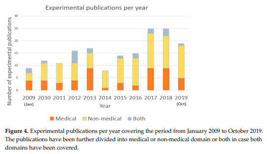

Yearly research by (Värbu, Muhammad, and Muhammad 2022)

In the current field of neuro-rehabilitation, BCI is used to engage patients to overcome paralysis or debilitating motor function. Using a BCI program, the patient can enhance their central nervous system (CNS) communication after a CNS issue, instead of using the current technology which is constraint-induced movement therapy (CIMT). CIMT promotes muscles to develop stronger than fixing the neuro-pathways. “We propose that addressing the speed and effectiveness of learning BCI control are priorities for the field, which may be improved by multimodal or multi-stage approaches harnessing more sensitive neuroimaging technologies in the early learning stages, before transitioning to more practical, mobile implementations.”(Simon et al. 2021) Therefore the patient tends to give up as there is a backup with CIMT, BCI is a new way of thinking of interacting with the motor function.

Currently EEG has the most adaptive paradigms for creating algorithms for hybrid-BCI (hBCI) collection and interpretation. By just reading the surface of the brain interaction, there may be effects like mental fatigue, information transfers at a lower rate, issues with multi-controls and false readings. They tested the hBCI which develops the EEG but also queues audio and visual. “Eight patients (four in the vegetative state (VS), three in the minimally conscious state (MCS), and one in the locked-in syndrome (LIS)) participated in the experiment. Using the SVM-based classifier, one VS patient, one MCS patient, and one LIS patient were able to select photos of themselves or others (classification accuracy, 66%–100%), which indicates that the patient command can be followed using an hybrid BCI and further proves that they have certain cognitive abilities and awareness.”(Zina Li and Pan 2019) The better engagement of BCI is the hybrid function as it allows the body to help the brain.

The medical field is about waiting until the patient is ready for physical activity, yet BCI integration would allow the healing to occur faster than the body could move. The current EEG decodes the brain activity into motor function and the patient has to relearn how to move their limbs with aid from the programmed EEG. “Current implementations of EEG-BCI are not well adapted for this purpose as they are cumbersome, require lengthy setup times with wet electrolyte-filled sensors, and a skilled operator to ensure sufficient signal quality, positioning of the headgear and execution of (often custom written and not user friendly) software.” (Simon et al. 2021) This causes the patient to get frustrated and is an easy way of giving up, as there is a backup in waiting for physical activity. The research suggests trying to get the patient to start with BCI and thinking about how they can move before trying physical therapy, as this would strengthen mind and body.

Exploratory research was designed to determine the multiple uses for BCI. “Researchers have, for instance, reported remarkable achievements demonstrating that BCI can efficiently restore capabilities of people with disabilities, such as those with schizophrenia symptoms (psychosis, emotional disturbances, and cognitive dysfunction)” (Maiseli et al., n.d.) The transition of just maintaining BCI and EEG has mutated to involving the whole body experience. “Humans have multiple senses that provide pathways for processing information on the reality. The integration of multiple sensory stimuli enhances top-down attention, and these enhanced effects may be conducive to improve the performance of BCI systems.”(Zina Li and Pan 2019)

The research that is available has explored the technology and potential that BCI can achieve, yet are there limitations to the security of those interactions and what are the threats that should be explored more? “The present study covers typical threat concerns, including medical safety, privacy, ethics, and security. Because the natural working principles of the brain are not comprehensively understood, researchers have been recommended to focus more on the short- and long-term impacts of BCI on the general welfare of humans.” (Maiseli et al., n.d.) The ethical dilemmas are being able to communicate to the brain in such a fashion or being able to store memories and ideas externally. Even more so, being able to control devices with the brain without the device owner’s consent. “Therefore, to address the privacy concerns, standards should be established to define acquisition methods, access control protocols, and encryption techniques, among other attributes.” (Maiseli et al., n.d.)

## Companies

There are currently 4 companies that are highlighted with pushing the BCI into the next phase of the technology. There should be some way of altering or combining what they have created to understand true interaction with the brain. “The BCI field is moving fast with a number of promising outcomes that can significantly improve human lives.” (Maiseli et al., n.d.) The goals each company has laid out are great to aspire for, yet some seem to stray away from their mark.

### Neuralink

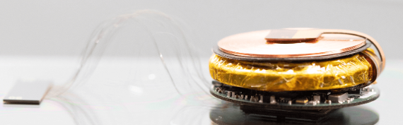

The Link device by (Neuralink 2023)

It is owned by Elon Musk with the goal of creating symbiotic relationship between brain and computer, initially to help those that have paralysis. Currently their product is not available to the public as it is intended to give back independence to those that require a medical device. They have created threads that are woven into the brain, attached to the synapses, to allow communication to different devices. “We believe this technology has the potential to treat a wide range of neurological disorders, to restore sensory and motor function, and eventually to expand how we interact with each other and experience the world around us.”(Neuralink 2023) They are designing a robotic system that can aid in the insertion of the device. “The Link” has an application to allow the user to access a keyboard, mouse, or mobile device via Bluetooth connection. “Through the Patient Registry, we expect to increase our understanding of the medical and assistive technology needs of individuals at a larger scale in order to thoughtfully design future clinical trials and neurotechnology devices that meet these individuals’ needs.” (Neuralink 2023) In December they opened patient registry for 5 conditions that they determined would be the best candidates for the device.

### Neurable

Starting with a deep dive of brain activity to being able to control different devices via EEG, they were most known for creating the world’s first brain-controlled VR game where the user would drive a car with an EEG headset. “We envisioned a roadmap for achieving a world with mental control of technology and affective computing (computers that can detect emotion), two new dimensions for how humans interact with machines.” (Molder 2023) Neurable changed their creating power to allow more customers to get their technology, as headphones are more used than VR devices. Enten monitors using brainwaves to ensure focus. The features for the headphones are vast, as they are the first iteration of ‘smart-headphones’ with touchless controls. The headphones increase the focus of the user and give data to increase knowledge of how the user can focus better. ” Neurotechology can achieve great things but are largely confined to laboratory settings because they are really hard to use and even more difficult to interpret.” (Molder 2023) Their proprietary algorithm and EEG creates jobs with the military and to make everyday BCI open to the public.

### BrainPort

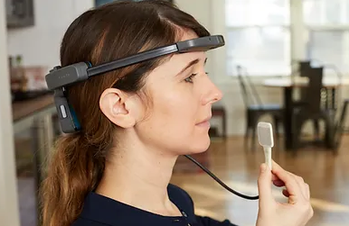

This company is less known here in the states since 2009 as their devices are more used in Europe. They have wearable devices for the blind to interpret sight via their tongue. There is an electric ‘lollipop’ that sends the signal to the brain to comprehend as a viewable object through training sessions. “The tongue array contains 394 electrodes and is connected to the headset via a flexible cable so it can’t be dropped and lost.” (Wicab 2023) This will stimulate the tongue to send feedback to the brain on what the camera sees. “A typical training course is 10 hours of one-on-one training, over a three-day period, including customized content for the individual user.” (Wicab 2023) This allows the user to sync with the device because it is not vision, but patterns on the tongue.

### Kernel

The goal is to store memories outside of the brain and upload new memories. The Flow was born out of this idea with integration of developing noninvasive precision neuroimaging. This device uses a near-infrared spectroscopy (TD-fNIRS) which is a imagining for high resolution observations. “Kernel is going to demonstrate that the best way to solve problems associated with the brain is to do so with precise measurement.” (various 2023) They have partnered with AppliedVR to measure treatment of chronic pain and are focusing on better developing aid for those with depression.

## Future of BCI

If I could continue my research on this subject, I would want to utilize the Neurable’s original technology: a VR game simulation with an EEG ‘controller’ to ensure the user can engage with the game’s methods. This would take some of the lab’s resources and programming to have the two devices communicate. Research does not show true evaluations on the products that are advancing BCI forward. There are evaluations on outdated methods. Regarding Kernel’s Flow, if we can map more of the brain, does that give the user more control? Any eternal BCI hinders the response and communication time from the brain to the computer. This might be solved with programming requirements to integrate machine learning for a better use and research outcome. With the current cyber security environment, the BCI community should consider the risk factors, security breaches and potential threats. All research should have a section dedicated to better understanding these risk factors.

## Conclusion

“The BCI field is moving fast with a number of promising outcomes that can significantly improve human lives. Researchers require regular updates to address challenges hindering further advancement of the BCI technology.” (Maiseli et al., n.d.) In my opinion, Neurable understands EEG, and Neuralink has a deep insight to BCI. Each company has their goals, yet all of them are moving towards noninvasive BCI. The approaches to understanding the brain are all the same. They differ in the implementation and branch of field in which they choose to work. My personal experience with EEG was it was hard to use, easy to interpret and not accurate. Below is the data from a short sleep I took to which the data was logged as being awake, alert, and thinking.

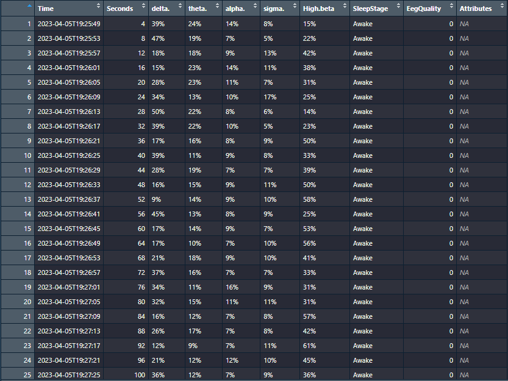

EEG Data Taken by Brainwave

EEG is hard to use from the user point, easy to use from a researchers point, yet the findings from both my personal experience and the research show that BCI needs to stop using EEG. It is affordable, portable, and outdated. EEG does not get the full map of the brain so we are not maximizing the communication that can occur. To have better brain interaction with the computer we need more senses to be engaged as we are humans with 5 senses. We must use them. Those research studies with hybrid analyses were the best data and better for the user. Hybrid meaning they had a VR headset, a tongue lollipop, or motor controls. But I am afraid that I have found the best way to communicate to the brain is invasive, as our neuroscience has not found a way to better respond to the brain with feedback. BCI is going to be a two-way street, to and from the computer. This requires synapse integration. I am looking forward to what these companies have in the pipeline for the future.

## References

Maiseli, Baraka Jacob, Libe Valentine Massawe, Mercy Mbise, Khadija Mkocha, Nassor Ally, Moses Ismail, James Michael, and Samwel Kimambo. n.d. “Brain Computer Interface: Future, Challenges, and Potential Threats.”

Molder, Adam. 2023. “Blog for Neurable.” Neuraable. 2023. https://neurable.com/blog/were-neurable.

Neuralink. 2023. “Approach.” Neuralink. 2023. https://neuralink.com/approach/.

Simon, Colin, David AE Bolton, Niamh C Kennedy, Surjo R Soekadar, and Kathy L Ruddy. 2021. “Challenges and Opportunities for the Future of Brain-Computer Interface in Neurorehabilitation.” *Frontiers in Neuroscience* 15: 699428.

Värbu, Kaido, Naveed Muhammad, and Yar Muhammad. 2022. “Past, Present, and Future of EEG-Based BCI Applications.” *Sensors* 22 (9): 3331.

various. 2023. “News for Kernel.” Kernel. 2023. https://www.kernel.com/news.

Wicab. 2023. “Vision-Pro.” Wicab, inc. 2023. https://www.wicab.com/brainport-vision-pro.

Zina Li, Shuqing Zhang, and Jiahui Pan. 2019. “Advances in Hybrid Brain-Computer Interfaces: Principles, Design, and Applications.” *Ergonomic Issues in Brain-Computer Interface Technologies: Current Status, Challenges, and Future Direction.*, no. 3807670.